# Mapas bivariados

Gabriel Massaine Moulatlet & Fabricio Villalobos

Instituto de Ecología, A.C.

## Paquetes

Vamos a utilizar los siguientes paquetes:

- `biscale`
- `ggplot2`

## Biscale

[figure not shown]

- Paquete para producir mapas bivariados (i.e. dos variables en el mismo layout)
  - Sirve para producir leyendas bivariadas
  - Herramientas para classificación de datos en categorías usando diferentes técnicas
  - [Documentación](https://chris-prener.github.io/biscale/index.html)

## Según Wikipedia…

- Mapas bivariados también son conocidos como *Mapa coropleto* o *Mapa de coropletas*

> Mapa temático en el que las áreas se sombrean de distintos colores, frecuentemente de la misma gama cromática, que representan distintos valores de una variable estadística característica.

## Dos o más variables…

- Los mapas bivariados son útiles para graficar dos variables
- Ajuste de colores, transparencias y formas

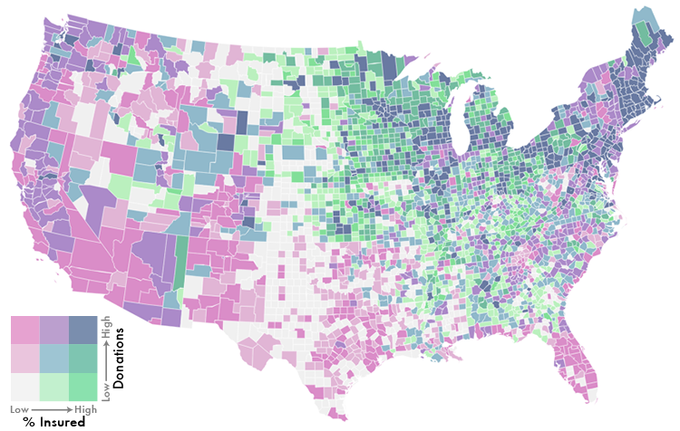

## Son bastante comunes para reportar resultados de elecciones

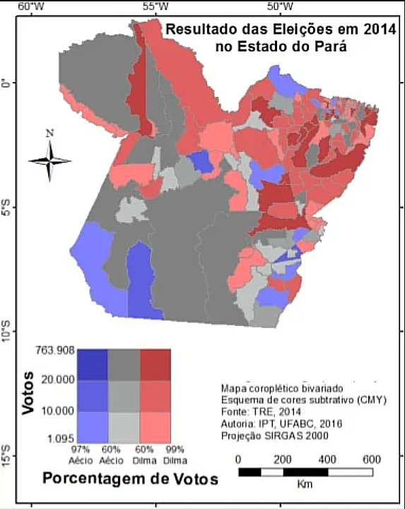

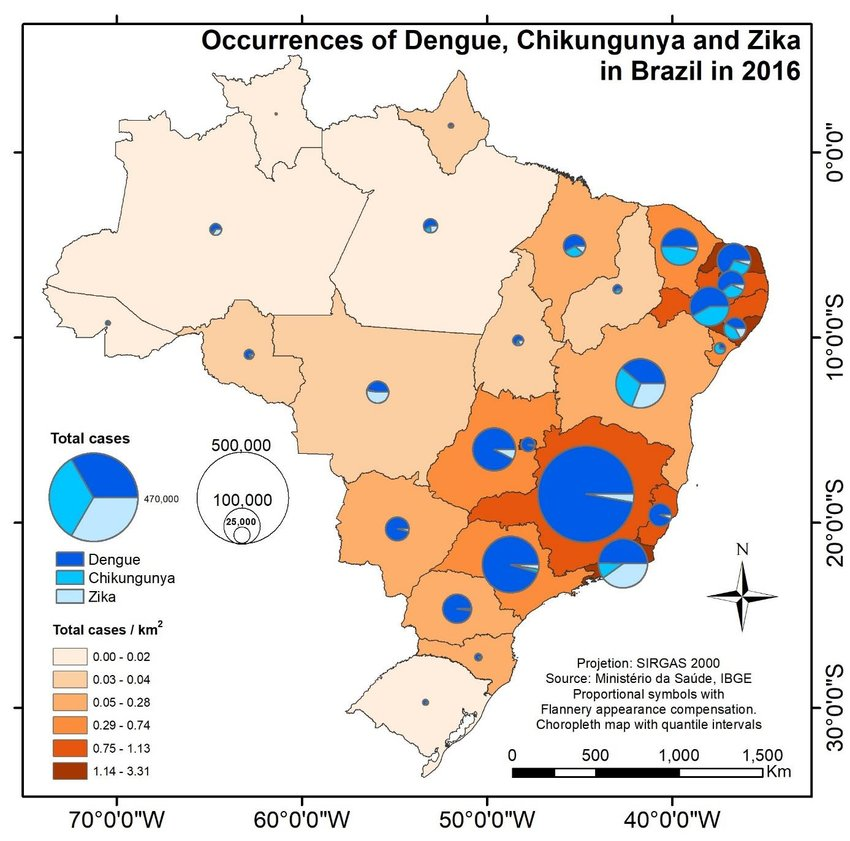

## Hay otros ejemplos: colores y marcaciones

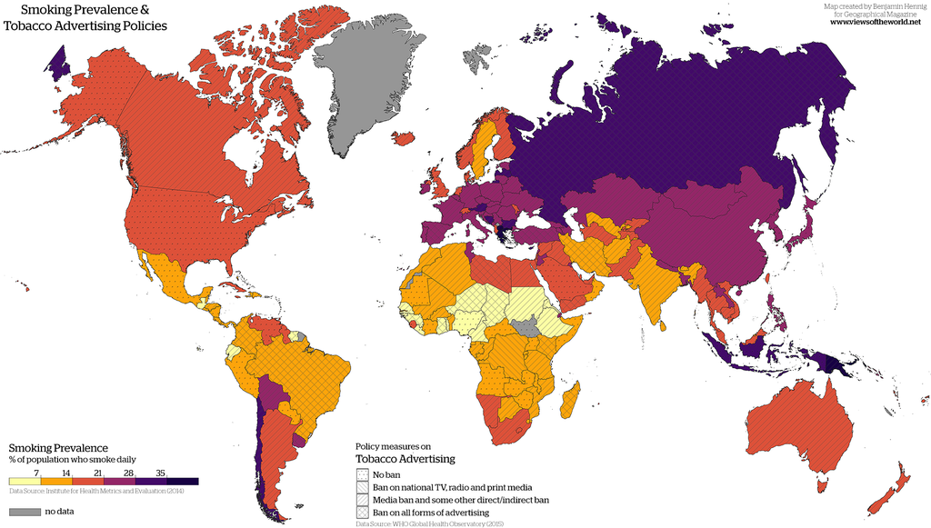

## Hay otros ejemplos: colores y area

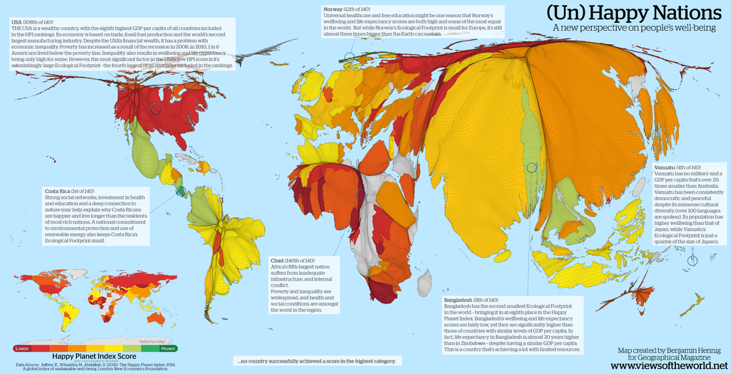

## Leyendas triangulares - Tres variables [Sabatini et al. 2022](https://onlinelibrary.wiley.com/doi/full/10.1111/ddi.13158)

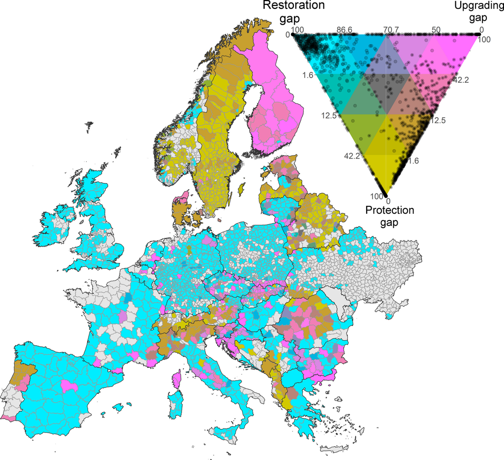

## Formatos complejos

[Sabatini et al. 2022](https://onlinelibrary.wiley.com/doi/full/10.1111/ddi.13158)

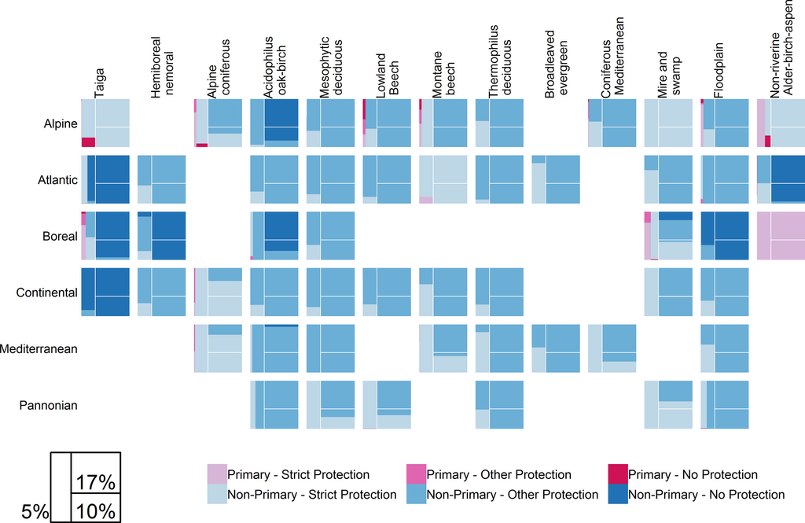

## Mapas RGB

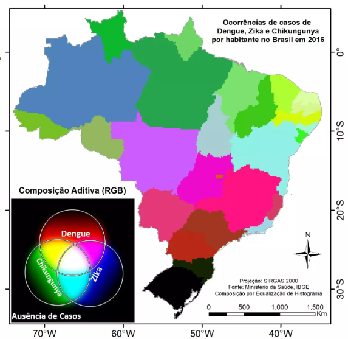

## Leyendas rectangulares con varias categorias

[Peixoto et al. 2017](https://onlinelibrary.wiley.com/doi/abs/10.1111/geb.12561)

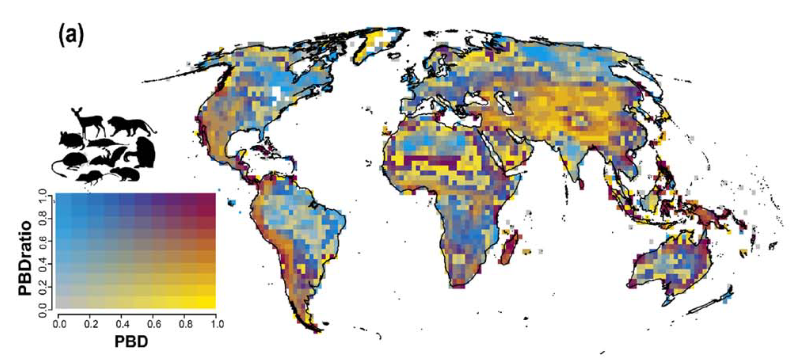

## Pero lo más importante es que la información esté clara

- ¿Cuál de los dos mapas transmite mejor la información?

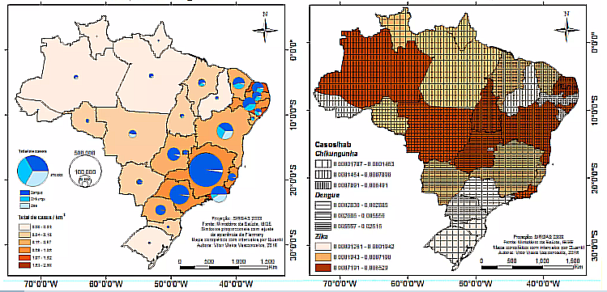

# Producir mapas bivariados

## Teoría:

- La idea central es buscar una manera de como combinar estas dos variables
- Escalas diferentes, número diferente de categorías etc…
- Los mapas bivariados conllevan dos pasos:
  1. Categorización de las variables según alguna estadística
  2. Preparación de una leyenda y su “paleta” de colores

# 1. Categorización de variables

## Pasos:

- Normalizar los datos en conteos o proporciones
- las funciones `cut()` y `summary()` de R base pueden ser útiles (revisar también `santoku`)
- Con los datos *iris*

```r
summary(iris$Sepal.Length)
```

```
   Min. 1st Qu.  Median    Mean 3rd Qu.    Max.
  4.300   5.100   5.800   5.843   6.400   7.900
```

```r
library(janitor)

# Categorizar de acuerdo a los quantiles
ci = cut(iris$Sepal.Length,
         breaks = c(4.3,5.1,5.8,6.4, max(iris$Sepal.Length)))

# Explorar los resultados
tabyl(ci)
```

```
        ci  n     percent valid_percent
 (4.3,5.1] 40 0.266666667     0.2684564
 (5.1,5.8] 39 0.260000000     0.2617450
 (5.8,6.4] 35 0.233333333     0.2348993
 (6.4,7.9] 35 0.233333333     0.2348993
      <NA>  1 0.006666667            NA
```

## la función `classIntervals()`

- Permite categorizar los datos usando varios tipos de categorización
- *quantile*, *jenkins*, *equal* para mencionar algunas
- hay que definir el numero de clases (parámetro *n*)

```r
library(classInt)

classInt::classIntervals(iris$Sepal.Length,style="quantile",n=4)
```

```
style: quantile
  one of 5,984 possible partitions of this variable into 4 classes
[4.3,5.1) [5.1,5.8) [5.8,6.4) [6.4,7.9]
       32        41        35        42
```

- Luego de categorizar el vector de interés, se puede cortar con la función `cut()`
- También se puede generar un vector con las categorías y juntarlo a los datos originales usando la función `findCols()`

```r
breaks = classInt::classIntervals(iris$Sepal.Length,style="quantile",n=4)$brks

cc = cut(iris$Sepal.Length, breaks = breaks)
tabyl(cc)
```

```
        cc  n     percent valid_percent
 (4.3,5.1] 40 0.266666667     0.2684564
 (5.1,5.8] 39 0.260000000     0.2617450
 (5.8,6.4] 35 0.233333333     0.2348993
 (6.4,7.9] 35 0.233333333     0.2348993
      <NA>  1 0.006666667            NA
```

## la función `findCols()`

```r
# Generar un vector que se pueda juntar a la tabla de datos originales

fc = findCols(classInt::classIntervals(iris$Sepal.Length,style="quantile",n=4))
head(fc)
```

```
[1] 2 1 1 1 1 2
```

## usando el paquete `biscale`

- Se utliza la función `bi_class()` para generar las catetorias
- Permite hacer la categorización de las dos variables elejidas de una vez, a diferencia de `classIntervals()`

```r
library(biscale)

data <- bi_class(iris, x = Sepal.Length, y = Petal.Length, style = "quantile", dim = 3)
head(data$bi_class)
```

```
[1] "1-1" "1-1" "1-1" "1-1" "1-1" "1-1"
```

# 2. Preparación de leyenda bivariada

## Preparación de una leyenda

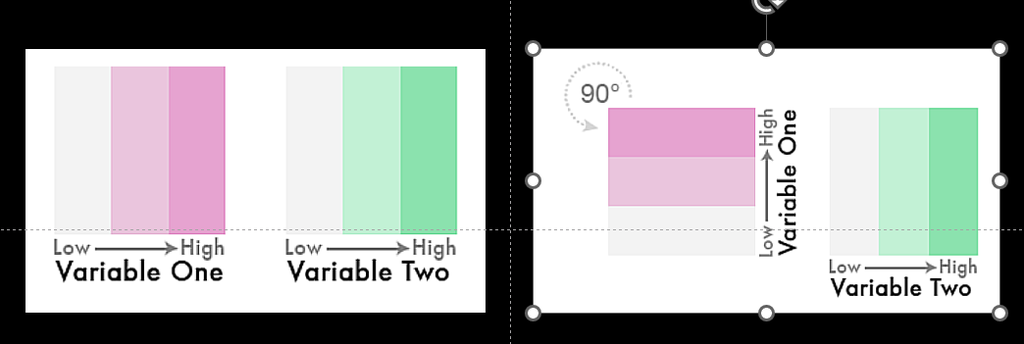

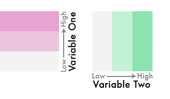

[figure not shown]

## La función `bi_legend()`

- Para ver las paletas disponibles [aquí](https://chris-prener.github.io/biscale/articles/bivariate_palettes.html)

```r
bi_legend(pal = "GrPink",
                    dim = 3,
                    xlab = "Sepal.Length",
                    ylab = "Petal.Lenght",
                    size = 12)
```

[figure not shown]

## El mapa bivariado

1. Vamos a ver el ejemplo del [vignette](https://chris-prener.github.io/biscale/articles/biscale.html)
- Son datos sobre el porcentaje de “brancos” y la ganancia en los EUA.
- Vamos usar las columnas `pctWhite` y `medInc` para hacer el mapa.
- Vamos usar 3 dimensiones y categorizar los datos usando `quantiles`

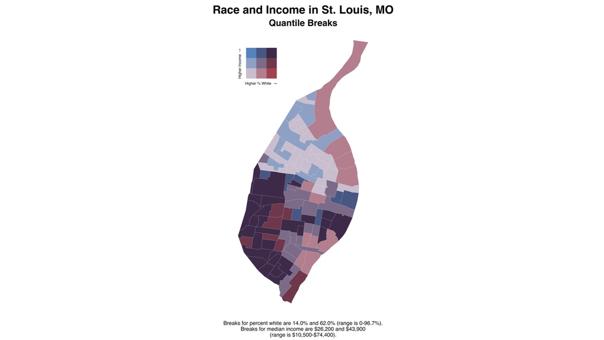

## Manos a la obra!

- Determinamos el geom como `geom_sf` y `fill=bi_class`
- `bi_class` debe ser la categorización que hemos visto anteriormente con `bi_class()`

```r
library(ggplot2)
library(sf)

data <- bi_class(stl_race_income, x = pctWhite, y = medInc, style = "quantile", dim = 3)

map <- ggplot() +
  geom_sf(data = data, mapping = aes(fill = bi_class), color = "white", size = 0.1, show.legend = FALSE) +
  bi_scale_fill(pal = "GrPink", dim = 3)
```

- `bi_scale_fill`, tiene el argumento `pal` para la paleta de colores y `dim` para el numero de categorías utilizadas
- Después de preparar el mapa, hay que preparar la leyenda

```r
legend <- bi_legend(pal = "GrPink",
                    dim = 3,
                    xlab = "Higher % White ",
                    ylab = "Higher Income ",
                    size = 8)
```

- Finalmente, ponerlos lado a lado usando `patchwork`

```r
library(patchwork)

map + legend
```

Se juede jugar con el layout final usando la función `inset`

p1 + inset_element(p2, 0.6, 0.6, 1, 1) # left, top, right, bottom

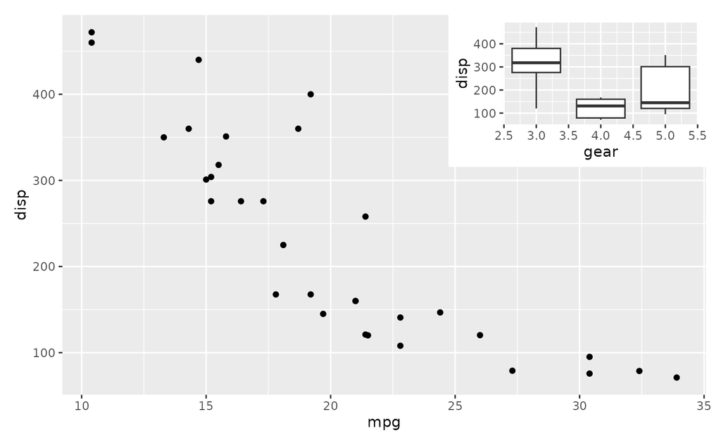

# Como hacer mapas bivariados sin usar el paquete `biscale`

- El tutorial de [Len Kiefer](http://lenkiefer.com/2017/04/24/bivariate-map/)
- Usar el paquete `classInt` para categorizar los datos
- Usar el esquema de colores de la leyenda para preparar el mapa

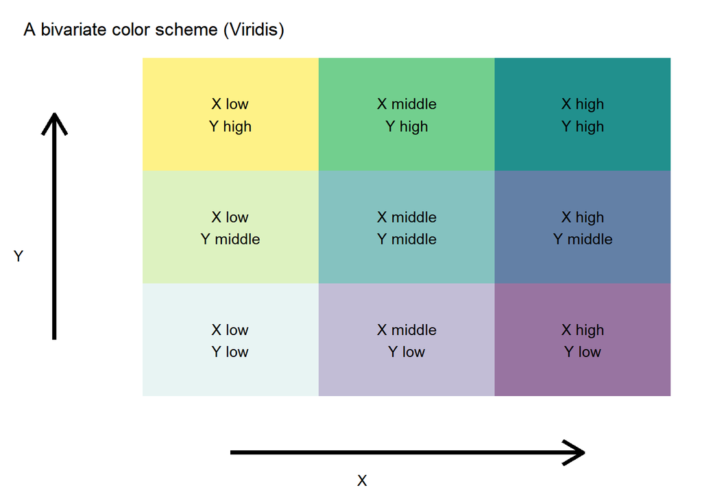

- Qué chulada!

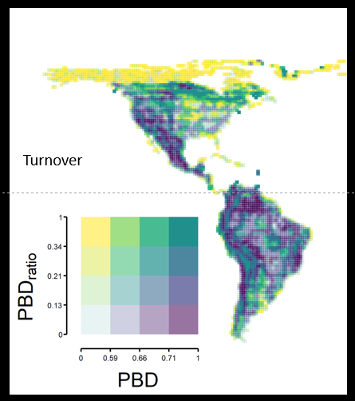

```r
library(tidyr)

d=expand.grid(x=1:3,y=1:3)
```

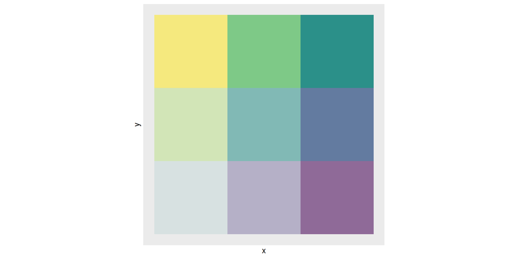

```r
library(ggplot2)
ggplot(d, aes(x,y))+
  geom_tile(aes(alpha=x+y,fill=atan(y/x)))+
  scale_fill_viridis_c()+
  theme(legend.position="none",
        axis.text.y = element_blank(),
        axis.text.x = element_blank(),
        axis.ticks = element_blank(),
        panel.grid.minor = element_blank(),
        panel.grid.major = element_blank())+
  coord_equal()
```

- Lo importante aqui es usar el geom `geom_tile`
- Permite usar varios [colores](https://ggplot2.tidyverse.org/reference/geom_tile.html)
- Vamos jugar con los valores de `alpha` (transparencia) y `fill`

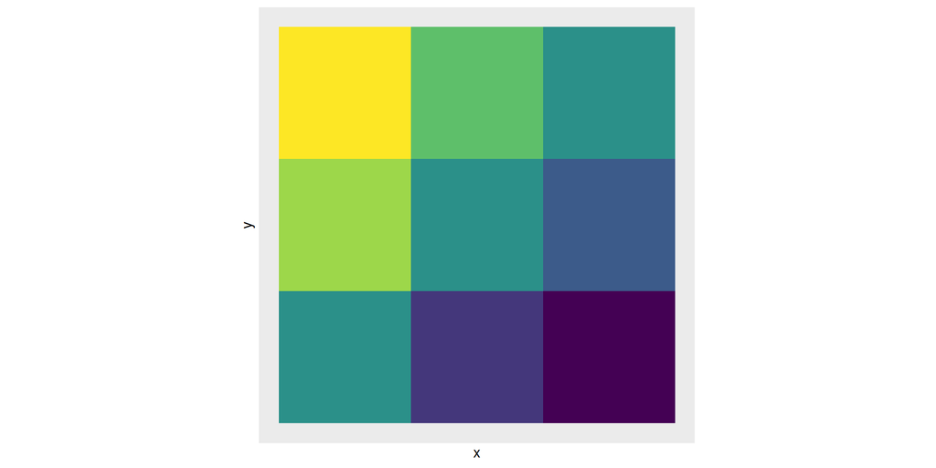

```r
ggplot(d, aes(x,y))+
  geom_tile(aes(fill=atan(y/x)))+
  scale_fill_viridis_c()+
  theme(legend.position="none",
        axis.text.y = element_blank(),
        axis.text.x = element_blank(),
        axis.ticks = element_blank(),
        panel.grid.minor = element_blank(),
        panel.grid.major = element_blank())+
  coord_equal()
```

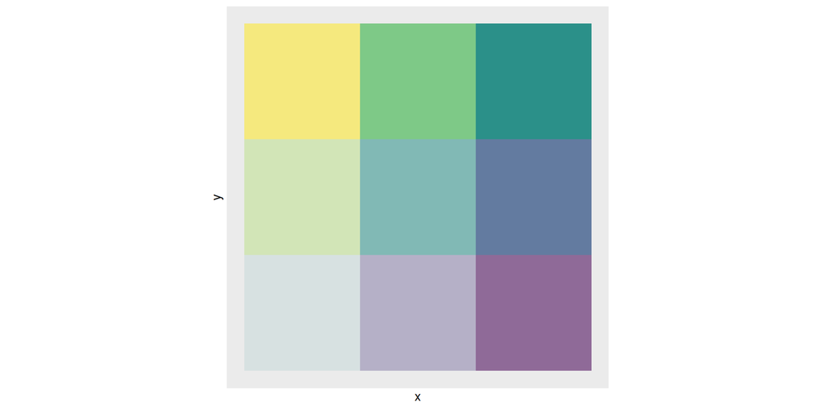

```r
ggplot(d, aes(x,y))+
  geom_tile(aes(fill=atan(y/x),alpha=x+y))+
  scale_fill_viridis_c()+
  theme(legend.position="none",
        axis.text.y = element_blank(),
        axis.text.x = element_blank(),
        axis.ticks = element_blank(),
        panel.grid.minor = element_blank(),
        panel.grid.major = element_blank())+
  coord_equal()
```

## Categorizar los datos

- vamos usar las funciones `classInt()` y `findCols()`

```r
 x=classInt::classIntervals(stl_race_income$pctWhite,
                            4,style = "quantile")
 y=classInt::classIntervals(stl_race_income$medInc,
                            4,style = "quantile")
```

```r
stl_race_income$x = classInt::findCols(x)
stl_race_income$y = classInt::findCols(y)
head(stl_race_income)
```

[output not shown]

## Crar un objeto para el `alpha` y otro para el `fill`

```r
stl_race_income$alpha = stl_race_income$x + stl_race_income$y
stl_race_income$color = atan(stl_race_income$y/stl_race_income$x)
```

## Graficar el mapa

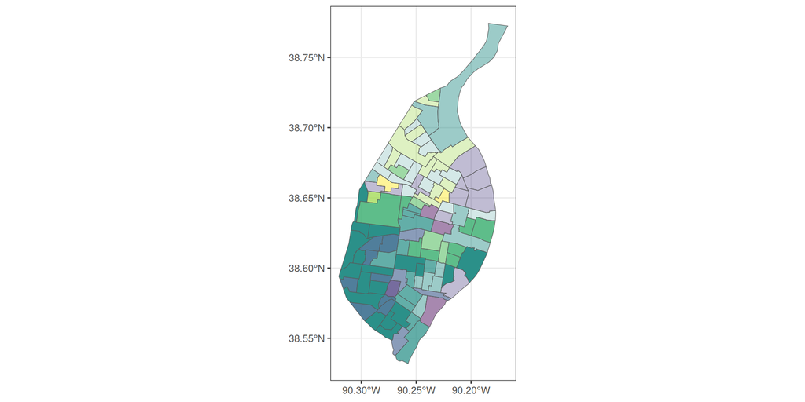

```r
map = ggplot()+
  #geom_sf(data=wrld)+
  geom_sf(data = stl_race_income, aes(fill = color, alpha = alpha), show.legend = FALSE)+
  scale_fill_viridis_c()+
  scale_alpha_continuous(range = c(0.2, 1))+
  theme_bw()
map
```

## Graficar la leyenda

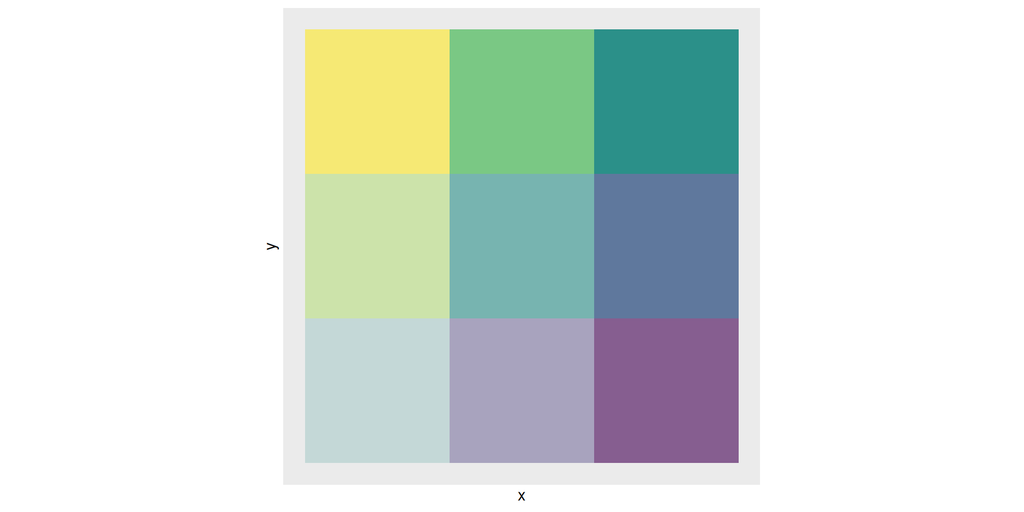

```r
leg = ggplot(d, aes(x,y))+
  geom_tile(aes(fill=atan(y/x),alpha=x+y))+
  scale_fill_viridis_c()+
  scale_alpha_continuous(range = c(0.2, 1))+
  theme(legend.position="none",
        axis.text.y = element_blank(),
        axis.text.x = element_blank(),
        axis.ticks = element_blank(),
        panel.grid.minor = element_blank(),
        panel.grid.major = element_blank())+
  coord_equal()
leg
```

## Juntar los dos

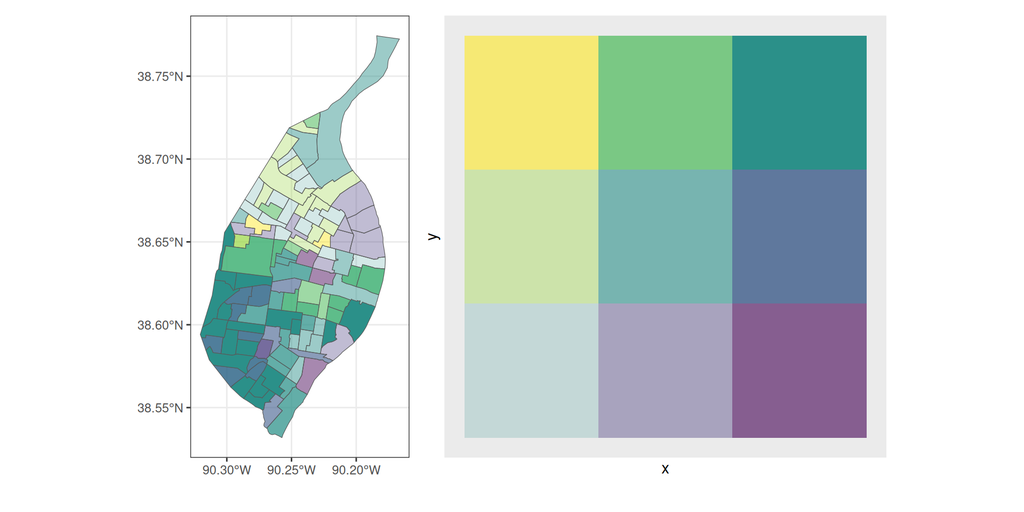

## Se parecen?

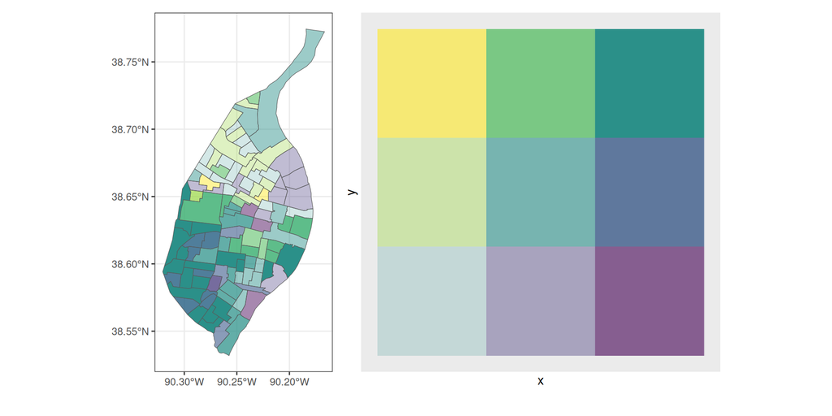

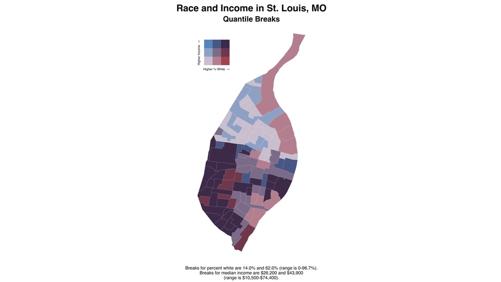

## Vamos hacer el mapa bivariado de la diversidad filogenetica de angiospermas en la Peninsula de Yucatán

1. Usando el paquete `biscale`
2. Manualmente

```r
# Los paquetes que vamos a utilizar
library(sf)
library(ggplot2)
library(rnaturalearth)
library(tidyterra)
library(classInt)
library(biscale)
```

## Cargar el mapa base

```r
wrld <- ne_countries(scale = "small",returnclass = "sf")
```

## Cargar los datos y ajustar el CRS

```r
resu = read.csv(file="dados_bivariate_maps.csv")
geo = st_as_sf(resu,coords = c(1,2))
st_crs(geo)= st_crs(wrld)
```

## 1. Preparar el mapa usando el paquete `biscale`

- Calcular las categorias

```r
cat <- bi_class(geo, x = TBD, y = PBD, style = "quantile", dim = 3)
```

## Preparar la leyenda

```r
leg =bi_legend(pal = "DkBlue",
          dim = 3,
          xlab = "Taxonomic beta",
          ylab = "Phylogenetic beta",
          size = 12)
```

## Preparar el mapa

```r
map =ggplot(data=wrld)+
  geom_sf()+
  geom_sf(data = cat, aes(color =  bi_class), size = 10, shape=15,show.legend = FALSE) +
  bi_scale_color(pal = "DkBlue", dim = 3)+
  theme_bw()+
  theme(panel.grid.major = element_blank())+
  coord_sf(xlim = c(-95, -86), ylim = c(16, 25), expand = FALSE)
map
```

## 2. Manualmente

- Crear un *grid*

```r
d<-expand.grid(x=1:3,y=1:3)
d
```

## Crear la leyenda

```r
leg2 =ggplot(d,aes(x,y))+

  #crear el *tile* jugando con los parámetros de colores *fill* y *alpha*
  geom_tile( aes(fill=atan(y/x),alpha=x+y))+
  scale_fill_viridis_c()+

  #Definir los temas
  theme(legend.position="none",
        panel.background=element_blank(),
        axis.text.y = element_blank(),
        axis.text.x = element_blank(),
        axis.ticks = element_blank(),
        axis.title.x = element_text(size=15,hjust=0.6),
        axis.title.y = element_text(size=15),
        panel.grid.minor = element_blank(),
        panel.grid.major = element_blank(),
        plot.background = element_rect(fill = "white",color="white"))+

  # Definir los titulos de los ejes
  labs(x="PBD",
       y="TBD")+

  # Decir que los tiles deben se cuadrados
  coord_equal()+

  # Poner flechitas
  geom_segment(aes(x=1, xend = 3 , y=0, yend = 0), size=1.5,
               arrow = arrow(length = unit(0.6,"cm"))) +
  geom_segment(aes(x=0, xend = 0 , y=1, yend = 3), size=1.5,
               arrow = arrow(length = unit(0.6,"cm")))
leg2
```

## Categorizar los datos

```r
catTBD = classInt::classIntervals(geo$TBD,3,style = "quantile")
catPBD = classInt::classIntervals(geo$PBD,3,style = "quantile")

# Juntar las columnas
geo$catTBD = classInt::findCols(catTBD)
geo$catPBD= classInt::findCols(catPBD)
```

## Hacer las columnas para el *alpha* (transparencia) y *color*

```r
geo$alpha = as.character(geo$catTBD + geo$catPBD)
geo$color  = as.character(atan(geo$catTBD/geo$catPBD))
```

## Hacer el mapa

```r
map2 = ggplot()+
  geom_sf(data=wrld)+
  geom_sf(data = geo,aes(color=color,alpha=alpha),shape=15, size=10,show.legend = FALSE)+
  scale_color_viridis_d()+
  theme_bw()+
  theme(panel.grid.major = element_blank())+
  coord_sf(xlim = c(-95, -86), ylim = c(16, 25), expand = FALSE)
map2
```

## Agregar la leyenda

```r
map + leg
map2 + leg2
```